# Querying CvTdb

The following are sample code and queries to use to query the CvTdb SQLite database.

Author

Taylor Wall

## 1 Background

### 1.1 CvTdb Summary

The Concentration versus Time Database (CvTdb) contains manually curated time-series data and associated metadata for in vivo studies on organic chemicals available in the scientific literature. These data inform chemical safety analysis and allow evaluation of the relationship between administered doses and internal concentrations of a substance. These data can also be used to build or evaluate physiologically based pharmacokinetic (PBPK) models, which simulate the absorption, distribution, metabolism, and elimination of a chemical. The database also contains toxicokinetic parameters, including volume of distribution and elimination half-life, which are calculated across all data associated with a particular compound using the publicly available pharmacokinetic curve-fitting software invivoPKfit. This version 2.0.0 release builds upon the original v1.0.0 “legacy” database released with Sayre, Wambaugh, and Grulke (2020) and the minor v1.1.0 database release from 2021 that added the Showa Pharmaceutical University dataset. The code, documentation, and vignettes associated with the database release are available on GitHub (CompTox-PK-CvTdb; [CvTdbLoad](https://github.com/USEPA/cvtdbload)). The database is also available for download through the public CCTE EPA [Clowder repository](https://doi.org/10.23645/epacomptox.29610452.v1) (no user account required).

> Sayre, R.R., Wambaugh, J.F. & Grulke, C.M (2020). Database of pharmacokinetic time-series data and parameters for 144 environmental chemicals. Sci Data 7(122). https://doi.org/10.1038/s41597-020-0455-1.

### 1.2 Credential Security

Although credentials are not required to use the provided CvTdb SQLite database, as a best practice one of the of the most important considerations to make when programmatically accessing databases is how to secure your database credentials. **NEVER HARDCODE CREDENTIALS**. Each programming language provides means to externalize such information and bring it into the environment. For `R`, the `.Renviron` file is where you can store your database connection credentials to then be used by the script.

> **Note:** When using online repositories like `GitHub` or `Bitbucket`, be sure to configure your `.gitignore` files appropriately so that your externalized credentials files (e.g., `.Renviron`, `.env`, etc.) are not uploaded with your code. An example .gitignore for `R` code has been provided. See [here](https://github.com/github/gitignore) for additional examples across coding languages.

An example .Renviron (R) or .env (Python) looks like the following, replacing the appropriate placeholders with their respective values:

```
user = "username-here"
password = "password-here"
host = "host-here"
database = "database-name-here"
```

### 1.3 Querying Databases in R

Queries in R can be made either by using pure SQL (as with the example `query_db()` example function below), or through dplyr notation (see [dplyr](https://db.rstudio.com/r-packages/dplyr/) and [dbplyr](https://dbplyr.tidyverse.org/) for additional information).

### 1.4 Querying Databases in Python

Queries in Python can be made using pure SQL (as with the example `query_db_python()` example function below) using the [pandas](https://pandas.pydata.org/docs/reference/api/pandas.read_sql_query.html) and [sqlalchemy](https://docs.sqlalchemy.org/en/20/intro.html) packages. Since this approach is a pure SQL approach where a user can input the same query, only the R approach will be shown below.

### 1.5 Database Schema Diagrams

An EER diagram shows how the tables are linked together, which helps with creating join queries. See [here](https://www.lucidchart.com/pages/ER-diagram-symbols-and-meaning) for help in reading the diagram.

## 2 Getting Started

### 2.1 Load required packages

R required packages

```r
library(DBI)
library(dplyr)
library(dbplyr)
# Additional database driver packages as needed:
## - RPostgres (PostgreSQL)
## - RMySQL (MySQL)
## - RSQLite (SQLite)
```

Python required packages

```python
import pandas as pd
# import sqlalchemy
# Additional database driver packages as needed:
## - psycopg2 (PostgreSQL)
## - mysql.connector (MySQL)
## - sqlite3 (SQLite)
```

### 2.2 Example Functions for Querying a Database

R Example Functions

```r
#'@description A function to make a connection to the database
#'@param con_type Whether to connect to postgres, mysql, or sqlite version
#'@import DBI RMySQL RSQLite RPostgres
#'@return Database connection pointer object
connect_to_db <- function(con_type){
  switch(con_type,
         "postgres" = dbConnect(RPostgres::Postgres(),
                                user = Sys.getenv("postgres_user"),
                                password = Sys.getenv("postgres_pass"), #
                                host = Sys.getenv("postgres_host"), #
                                dbname = Sys.getenv("postgres_dbname")),
         "mysql" = dbConnect(RMySQL::MySQL(), #Connect to database with .Renviron parameters
                             username = Sys.getenv("mysql_user"),
                             password = Sys.getenv("mysql_pass"),
                             host = Sys.getenv("mysql_host"),
                             port = 3306,
                             dbname = Sys.getenv("mysql_dbname")),
         'sqlite' = dbConnect(RSQLite::SQLite(), paste0(Sys.getenv("sqlite_dbname"), ".sqlite"))
  ) %>% return()
}

#'@description Function to query database and receive the results.
#'Handles errors/warnings with tryCatch.
#'@param query A SQL query string to query the database with
#'@param con_type Whether to connect to postgres, mysql, or sqlite version
#'@param schema The schema name to use if using a postgresql connection
#'@import DBI dplyr
#'@return Dataframe of database query results
query_db <- function(query=NULL, con_type, schema){
  if(is.null(query)) return(cat("\nMust provide a query to send"))
  con = connect_to_db(con_type)

  query_result = tryCatch({
    if(con_type == "postgres"){# Add schema tag
      return(dbGetQuery(con, query %>%
                          gsub("FROM ", paste0("FROM ",schema,"."), .) %>%
                          gsub("JOIN ", paste0("JOIN ",schema,"."), .)
                        ))
    } else {
      return(dbGetQuery(con, query))
    }
  },
  error=function(cond){ cat(paste0("\nError message: ", cond)); return(NULL) },
  finally={ dbDisconnect(con) })

  return(query_result)
}

#' @description Function to compare outputs between pure SQL and dbplyr approaches.
#' @return None. Print statement is returned of whether the last output was identical or not.
compare_sql_dbplyr <- function(){
  if(exists("df_sql") && exists("df_dbplyr")){
    ifelse(identical(df_sql, df_dbplyr),
                 "SQL and dplyr version outputs are identical",
                 "SQL and dplyr version outputs are NOT identical")
    }
}
```

Python Example Functions

```python
def query_db_python(query):
  """
  Returns a Pandas DataFrame with the query results from a Postgres database.
  Handles errors with Exceptions.

  Parameters
  ----------
  query: str, required
    A SQL query string to query the database with.

  Returns
  -------
  pandas.DataFrame
    The queried results in a Pandas DataFrame object.
  """
  if not query:
    print("Must provide a SQL query")
    return None

  con = sqlite3.connect("res_cvtdb.sqlite")

  try:
    return pd.read_sql_query(query, con)
  except Exception as e:
    print(e)
    return None
  finally:
    con.close()
```

## 3 Querying CvTdb

### 3.1 CvTdb EER Diagram

The following is the EER diagram for CvTdb. The basic tables and connections are:

- documents
  - id
- studies
  - id
  - fk_extraction_document_id –> documents.id
  - fk_reference_document_id –> documents.id
  - fk_dosed_chemical_id –> chemicals.id
- subjects
  - id
- series
  - id
  - fk_study_id –> studies.id
  - fk_subject_id –> subjects.id
  - fk_analyzed_chemical_id –> chemicals.id
- conc_time_values
  - fk_series_id –> series.id
- chemicals
  - id

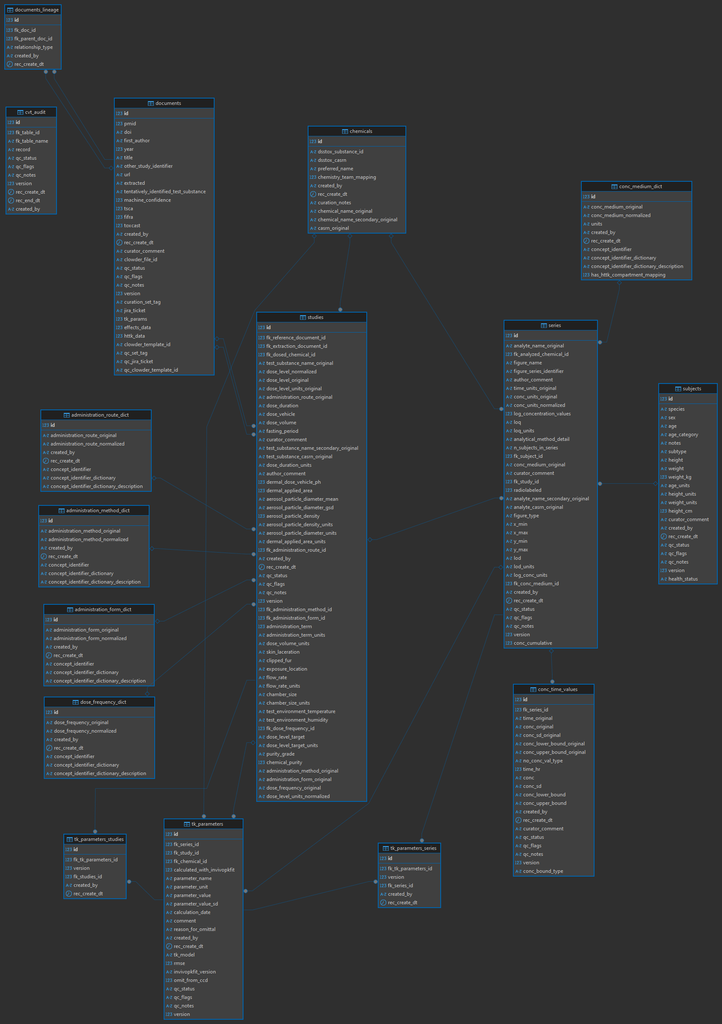

CvTdb EER Diagram

### 3.2 Sample Queries

All sample queries below provide the pure `SQL` and `dplyr` approaches in tabbed format using R. For Python, a similar pure `SQL` approach can be accomplished, so only the R approach is shown here.

#### 3.2.1 Query CvTdb “documents” Table

The following is a query to pull records from the `documents` table that lists a few document identifiers.

**df_sql**

```
query <- paste0("SELECT pmid, year, first_author, title ",
                "FROM documents WHERE first_author IS NOT NULL AND ",
                "title IS NOT NULL LIMIT 15")

df_sql <- query_db(query = query, con_type = "sqlite")
```

| pmid | year | first_author | title |
| --- | --- | --- | --- |
| 2318350 | 1990 | Cheever | Ethylene dichloride: the influence of disulfiram or ethanol on oncogenicity, metabolism, and DNA covalent binding in rats |
| 3813877 | 1986 | Igwe | Inhalation pharmacokinetics of 1,2-dichloroethane after different dietary pretreatments of male Sprague-Dawley rats |
| 2077699 | 1990 | T Kyrklund | Brain lipid changes after organic solvent exposure |
| 1048 | 1975 | A Cova | Flavoxate and 3-methylflavone-8-carboxylic acid. Assay methods in blood and urine, plasma-red cells repartition and stability |
| 1051 | 1975 | E Liss | The distribution and elimination of radioactivity in the rat after administration of 14C-4-acetamidophenyl-2-acetoxybenzoate (benorylate) |
| 1219 | 1975 | K B Alton | Comparative biotransformation of triflubazam in rats, dogs, and monkeys |
| 1220 | 1975 | D J Tocco | Physiological disposition and metabolism of 5-(2',4'-difluorophenyl)salicyclic acid, a new salicylate |
| 1221 | 1975 | A Karim | Spironolactone metabolism in man studied by gas chromatography-mass spectrometry |
| 1223 | 1975 | R L Chang | Correlation of 14C-griseofulvin metabolism in rat liver microsomes, isolated perfused rat livers, and in rats with bile duct cannulas |
| 1230 | 1975 | A L Hunter | Biliary excretion of colchicine in newborn rats |

[output cut: 5 more lines]

**df_dbplyr**

```
con <- connect_to_db(con_type = "sqlite")

# Wrapped in a tryCatch so the connection is always closed in case of error
df_dbplyr <- tryCatch(
  {
    tbl(con, "documents") %>%
      head(15) %>%
      select(pmid, year, first_author, title) %>%
      filter(!is.na(first_author), !is.na(title)) %>%
      collect() %>%
      as.data.frame()
  },
  error=function(e) {
    message(e)
    return(NULL)
  },
  finally={
    dbDisconnect(con)
  }
)
```

| pmid | year | first_author | title |
| --- | --- | --- | --- |
| 2318350 | 1990 | Cheever | Ethylene dichloride: the influence of disulfiram or ethanol on oncogenicity, metabolism, and DNA covalent binding in rats |
| 3813877 | 1986 | Igwe | Inhalation pharmacokinetics of 1,2-dichloroethane after different dietary pretreatments of male Sprague-Dawley rats |
| 2077699 | 1990 | T Kyrklund | Brain lipid changes after organic solvent exposure |
| 1048 | 1975 | A Cova | Flavoxate and 3-methylflavone-8-carboxylic acid. Assay methods in blood and urine, plasma-red cells repartition and stability |
| 1051 | 1975 | E Liss | The distribution and elimination of radioactivity in the rat after administration of 14C-4-acetamidophenyl-2-acetoxybenzoate (benorylate) |
| 1219 | 1975 | K B Alton | Comparative biotransformation of triflubazam in rats, dogs, and monkeys |
| 1220 | 1975 | D J Tocco | Physiological disposition and metabolism of 5-(2',4'-difluorophenyl)salicyclic acid, a new salicylate |
| 1221 | 1975 | A Karim | Spironolactone metabolism in man studied by gas chromatography-mass spectrometry |
| 1223 | 1975 | R L Chang | Correlation of 14C-griseofulvin metabolism in rat liver microsomes, isolated perfused rat livers, and in rats with bile duct cannulas |
| 1230 | 1975 | A L Hunter | Biliary excretion of colchicine in newborn rats |

[output cut: 5 more lines]

#### 3.2.2 Pull all data by input document identifier

A user can also filter the `documents` table by document identifiers, such as a PMID ([PubMed ID](https://pubmed.ncbi.nlm.nih.gov/)), and join to other database tables to pull all study, subject, series, and concentration data associated with selected documents.

**df_sql**

```
# PMID list of interest
pmid_list <- c('43370', '422270', '422271', '538758', '629888', '731724', '734422', '843463', '843464', '926203')

            # Select columns of interest
query <- paste0(
            "SELECT distinct e.pmid, b.analyte_name_original,
            c.dose_level_original, c.dose_level_units_original, ",
            "d.species, b.conc_medium_original,
            a.time_original, b.time_units_original,
            a.conc_original, b.conc_units_original ",
            "FROM conc_time_values a ",
            # Join to series table by series ID
            "LEFT JOIN series b on b.id = a.fk_series_id ",
            # Join to studies table by study ID
            "LEFT JOIN studies c on c.id = b.fk_study_id ",
            # Join to subjects table by subject ID
            "LEFT JOIN subjects d on d.id = b.fk_subject_id ",
            # Join to documents table by extraction document ID
            "LEFT JOIN documents e on c.fk_extraction_document_id = e.id ",
            # Filter to PMID of interest
            "WHERE e.pmid in ('",
            # Using paste instead of toString() for cases where identifiers
            # are alphanumeric strings
            paste0(pmid_list, collapse="', '"),
            "')")

df_sql <- query_db(query = query,
           con_type = "sqlite")
```

| pmid | test_substance_name_original | analyte_name_original | dose_level_original | dose_level_units_original | species | conc_medium_original | time_original | time_units_original | conc_original | conc_units_original |
| --- | --- | --- | --- | --- | --- | --- | --- | --- | --- | --- |
| 629888 | trichloroethylene | trichloroethylene | 100 | % | human | breath | 0.25 | hours | 0.81 | umol/L |
| 629888 | trichloroethylene | trichloroethylene | 100 | % | human | breath | 0.5 | hours | 0.441 | umol/L |
| 629888 | trichloroethylene | trichloroethylene | 100 | % | human | breath | 0.75 | hours | 0.27600000000000002 | umol/L |
| 629888 | trichloroethylene | trichloroethylene | 100 | % | human | breath | 2.5 | hours | 8.5999999999999993E-2 | umol/L |
| 629888 | trichloroethylene | trichloroethylene | 100 | % | human | breath | 3.5 | hours | 4.9000000000000002E-2 | umol/L |
| 629888 | trichloroethylene | trichloroethylene | 100 | % | human | breath | 6 | hours | 0.03 | umol/L |
| 629888 | trichloroethylene | trichloroethylene | 100 | % | human | breath | 7 | hours | 2.7E-2 | umol/L |
| 629888 | trichloroethylene | trichloroethylene | 100 | % | human | breath | 7.5 | hours | 2.1000000000000001E-2 | umol/L |
| 629888 | trichloroethylene | trichloroethylene | 100 | % | human | breath | 8 | hours | 2.1000000000000001E-2 | umol/L |
| 629888 | trichloroethylene | trichloroethylene | 100 | % | human | breath | 9 | hours | 1.6E-2 | umol/L |

[output cut: 896 more lines]

**df_dbplyr**

```
# PMID list of interest
pmid_list <- c('43370', '422270', '422271', '538758', '629888', '731724', '734422', '843463', '843464', '926203')

con <- connect_to_db(con_type = "sqlite")

# Wrapped in a tryCatch so the connection is always closed in case of error
df_dbplyr <- tryCatch(
  {
    # Store table pointers with column name prefixes
    conc = tbl(con, "conc_time_values") %>% rename_all(function(x) paste0("a.", x))
    series = tbl(con, "series") %>% rename_all(function(x) paste0("b.", x))
    studies = tbl(con, "studies") %>% rename_all(function(x) paste0("c.", x))
    subjects = tbl(con, "subjects") %>% rename_all(function(x) paste0("d.", x))
    docs = tbl(con, "documents") %>% rename_all(function(x) paste0("e.", x))

    out <- conc %>%
      left_join(series,
                by=c("a.fk_series_id"="b.id")) %>%
      left_join(studies,
                by=c("b.fk_study_id"="c.id")) %>%
      left_join(subjects,
                by=c("b.fk_subject_id"="d.id")) %>%
      left_join(docs,
                by=c("c.fk_extraction_document_id"="e.id")) %>%
      filter(e.pmid %in% pmid_list) %>%
      select(e.pmid, b.analyte_name_original, c.dose_level_original,
             c.dose_level_units_original, d.species, b.conc_medium_original,
             a.time_original, b.time_units_original, a.conc_original, b.conc_units_original) %>%
      distinct() %>%
      collect() %>%
      as.data.frame()

    # Remove column prefixes
    colnames(out) = sub('.*\\.', '', colnames(out))

    out

  },
  error=function(e) {
    message(e)
    return(NULL)
  },
  finally={
    dbDisconnect(con)
  }
)
```

| pmid | test_substance_name_original | analyte_name_original | dose_level_original | dose_level_units_original | species | conc_medium_original | time_original | time_units_original | conc_original | conc_units_original |
| --- | --- | --- | --- | --- | --- | --- | --- | --- | --- | --- |
| 629888 | trichloroethylene | trichloroethylene | 100 | % | human | breath | 0.25 | hours | 0.81 | umol/L |
| 629888 | trichloroethylene | trichloroethylene | 100 | % | human | breath | 0.5 | hours | 0.441 | umol/L |
| 629888 | trichloroethylene | trichloroethylene | 100 | % | human | breath | 0.75 | hours | 0.27600000000000002 | umol/L |
| 629888 | trichloroethylene | trichloroethylene | 100 | % | human | breath | 2.5 | hours | 8.5999999999999993E-2 | umol/L |
| 629888 | trichloroethylene | trichloroethylene | 100 | % | human | breath | 3.5 | hours | 4.9000000000000002E-2 | umol/L |
| 629888 | trichloroethylene | trichloroethylene | 100 | % | human | breath | 6 | hours | 0.03 | umol/L |
| 629888 | trichloroethylene | trichloroethylene | 100 | % | human | breath | 7 | hours | 2.7E-2 | umol/L |
| 629888 | trichloroethylene | trichloroethylene | 100 | % | human | breath | 7.5 | hours | 2.1000000000000001E-2 | umol/L |
| 629888 | trichloroethylene | trichloroethylene | 100 | % | human | breath | 8 | hours | 2.1000000000000001E-2 | umol/L |
| 629888 | trichloroethylene | trichloroethylene | 100 | % | human | breath | 9 | hours | 1.6E-2 | umol/L |

[output cut: 896 more lines]

#### 3.2.3 Pull dosed and analyzed chemical data by chemical identifier

An example of querying dosed and analyzed chemical data using input chemical identifiers like DTXSID ([EPA DSSTox Identifiers](https://www.epa.gov/comptox-tools/distributed-structure-searchable-toxicity-dsstox-database)).

**df_sql**

```
# DTXSID list of interest
dtxsid_list <- c('DTXSID0021383', 'DTXSID2020139', 'DTXSID0020868', 'DTXSID4020533', 'DTXSID0020442')

            # Select columns of interest
query <- paste0(
  "SELECT distinct ",
  # Studies table fields
  "c.fk_dosed_chemical_id, ",
  ## Chemical dictionary fields (dosed chemical information)
  "k.dosed_chem_dtxsid, k.dosed_chem_name_original, k.dosed_chem_casrn, k.dosed_chem_name, ",
  # Series table fields
  "b.fk_analyzed_chemical_id, ",
  ## Chemical dictionary fields (analyzed chemical information)
  "l.analyzed_chem_dtxsid, l.analyzed_chem_name_original, l.analyzed_chem_casrn, l.analyzed_chem_name, ",
  "b.radiolabeled, ",
  ## conc_medium dictionary fields
  "b.conc_medium_original, i.conc_medium_normalized, ",
  ## administration_route dictionary fields
  "c.administration_route_original, h.administration_route_normalized, ",
  ## administration_method dictionary fields
  "c.administration_method_original, g.administration_method_normalized, ",
  ## administration_form dictionary fields
  "c.administration_form_original, f.administration_form_normalized ",

  # Join with series table by series ID
  "FROM series b ",

  # Join to studies table by study ID
  "LEFT JOIN studies c ON b.fk_study_id = c.id ",

  # Join to dictionary tables
  "LEFT JOIN administration_form_dict f ON c.fk_administration_form_id = f.id ",
  "LEFT JOIN administration_method_dict g ON c.fk_administration_method_id = g.id ",
  "LEFT JOIN administration_route_dict h ON c.fk_administration_route_id = h.id ",
  "LEFT JOIN conc_medium_dict i ON b.fk_conc_medium_id = i.id ",

  # Rename chemical fields for dosed vs. analyzed chemical record foreign keys
  "LEFT JOIN (SELECT id, dsstox_substance_id as dosed_chem_dtxsid, ",
  "chemical_name_original as dosed_chem_name_original, dsstox_casrn as dosed_chem_casrn, preferred_name as dosed_chem_name ",
  "FROM chemicals) as k ON c.fk_dosed_chemical_id = k.id ",
  "LEFT JOIN (SELECT id, dsstox_substance_id as analyzed_chem_dtxsid, ",
  "chemical_name_original as analyzed_chem_name_original, dsstox_casrn as analyzed_chem_casrn, preferred_name as analyzed_chem_name ",
  "FROM chemicals) as l ON b.fk_analyzed_chemical_id = l.id ",

  # Filtering steps
  "WHERE k.dosed_chem_dtxsid in ('", paste0(dtxsid_list, collapse = "', '"),
  "') OR l.analyzed_chem_dtxsid in ('", paste0(dtxsid_list, collapse = "', '"), "')"
)

df_sql <- query_db(query = query,
           con_type = "sqlite")
```

| fk_dosed_chemical_id | dosed_chem_dtxsid | dosed_chem_name_original | dosed_chem_casrn | dosed_chem_name | fk_analyzed_chemical_id | analyzed_chem_dtxsid | analyzed_chem_name_original | analyzed_chem_casrn | analyzed_chem_name | radiolabeled | conc_medium_original | conc_medium_normalized | administration_route_original | administration_route_normalized | administration_method_original | administration_method_normalized | administration_form_original | administration_form_normalized |
| --- | --- | --- | --- | --- | --- | --- | --- | --- | --- | --- | --- | --- | --- | --- | --- | --- | --- | --- |
| 988 | DTXSID2020139 | benzo(a)pyrene | 50-32-8 | Benzo[a]pyrene | 989 | DTXSID7038319 | 3-hydroxybenzo(a)pyrene | 13345-21-6 | 3-Hydroxybenz[a]pyrene | 0 | liver | liver | iv | iv |  |  |  |  |
| 988 | DTXSID2020139 | benzo(a)pyrene | 50-32-8 | Benzo[a]pyrene | 989 | DTXSID7038319 | 3-hydroxybenzo(a)pyrene | 13345-21-6 | 3-Hydroxybenz[a]pyrene | 0 | urine | urine | iv | iv |  |  |  |  |
| 9 | DTXSID0020868 | dichloromethane | 75-09-2 |  | 9 | DTXSID0020868 | dichloromethane | 75-09-2 |  |  | liver | liver | iv | iv |  |  |  |  |
| 9 | DTXSID0020868 | dichloromethane | 75-09-2 |  | 987 |  | [14]C |  |  | 1 | liver | liver | iv | iv |  |  |  |  |
| 9 | DTXSID0020868 | dichloromethane | 75-09-2 |  | 9 | DTXSID0020868 | dichloromethane | 75-09-2 |  |  | kidney | kidney | iv | iv |  |  |  |  |
| 892 | DTXSID0021383 | trichloroethylene | 79-01-6 | Trichloroethylene | 1001 | DTXSID1021950 | trichloroethanol | 115-20-8 | 2,2,2-Trichloroethanol | 0 | urine | urine | inhalation | inhalation | whole-body |  | vapor |  |
| 882 | DTXSID2020139 | benzo[a]pyrene | 50-32-8 | Benzo[a]pyrene | 262 | DTXSID80881374 | [3]H | 10028-17-8 |  | 1 | central blood | blood | iv | iv |  |  |  |  |
| 13 | DTXSID4020533 | 1,4-Dioxane | 123-91-1 |  | 1168 | DTXSID70158385 | hydroxyethoxyacetic acid | 13382-47-3 |  |  | blood | blood | oral | oral | gavage |  |  |  |
| 882 | DTXSID2020139 | benzo[a]pyrene | 50-32-8 | Benzo[a]pyrene | 262 | DTXSID80881374 | [3]H | 10028-17-8 |  | 1 | central blood | blood | oral | oral | gavage |  |  |  |
| 1169 | DTXSID2020139 | benzo(a)pyrene | 50-32-8 |  | 1169 | DTXSID2020139 | benzo(a)pyrene | 50-32-8 |  |  | fat | adipose | iv | iv |  |  |  |  |

[output cut: 101 more lines]

**df_dbplyr**

```
# DTXSID list of interest
dtxsid_list <- c('DTXSID0021383', 'DTXSID2020139', 'DTXSID0020868', 'DTXSID4020533', 'DTXSID0020442')

con <- connect_to_db(con_type = "sqlite")

# Wrapped in a tryCatch so the connection is always closed in case of error
df_dbplyr <- tryCatch(
  {
    # Store table pointers with column name prefixes
    series = tbl(con, "series") %>% rename_all(function(x) paste0("b.", x))
    studies = tbl(con, "studies") %>% rename_all(function(x) paste0("c.", x))

    administration_form_dict = tbl(con, "administration_form_dict") %>%
      rename_all(function(x) paste0("f.", x))
    administration_method_dict = tbl(con, "administration_method_dict") %>%
      rename_all(function(x) paste0("g.", x))
    administration_route_dict = tbl(con, "administration_route_dict") %>%
      rename_all(function(x) paste0("h.", x))
    conc_medium_dict = tbl(con, "conc_medium_dict") %>%
      rename_all(function(x) paste0("i.", x))

    dosed_chemicals = tbl(con, "chemicals") %>%
      dplyr::select(id, dosed_chem_dtxsid = dsstox_substance_id,
                    dosed_chem_name_original = chemical_name_original,
                    dosed_chem_casrn = dsstox_casrn,
                    dosed_chem_name = preferred_name) %>%
      rename_all(function(x) paste0("k.", x))

    analyzed_chemicals = tbl(con, "chemicals") %>%
      dplyr::select(id, analyzed_chem_dtxsid = dsstox_substance_id,
                    analyzed_chem_name_original = chemical_name_original,
                    analyzed_chem_casrn = dsstox_casrn,
                    analyzed_chem_name = preferred_name) %>%
      rename_all(function(x) paste0("l.", x))

    out <- series %>%
      left_join(studies,
                by=c("b.fk_study_id"="c.id")) %>%
      left_join(administration_route_dict,
                by=c("c.fk_administration_route_id"="h.id")) %>%
```

[output cut: 32 more lines]

```

    # Remove column prefixes
    colnames(out) = sub('.*\\.', '', colnames(out))

    out

  },
  error=function(e) {
    message(e)
    return(NULL)
  },
  finally={
    dbDisconnect(con)
  }
)
```

| fk_dosed_chemical_id | dosed_chem_dtxsid | dosed_chem_name_original | dosed_chem_casrn | dosed_chem_name | fk_analyzed_chemical_id | analyzed_chem_dtxsid | analyzed_chem_name_original | analyzed_chem_casrn | analyzed_chem_name | radiolabeled | conc_medium_original | conc_medium_normalized | administration_route_original | administration_route_normalized | administration_method_original | administration_method_normalized | administration_form_original | administration_form_normalized |
| --- | --- | --- | --- | --- | --- | --- | --- | --- | --- | --- | --- | --- | --- | --- | --- | --- | --- | --- |
| 988 | DTXSID2020139 | benzo(a)pyrene | 50-32-8 | Benzo[a]pyrene | 989 | DTXSID7038319 | 3-hydroxybenzo(a)pyrene | 13345-21-6 | 3-Hydroxybenz[a]pyrene | 0 | liver | liver | iv | iv |  |  |  |  |
| 988 | DTXSID2020139 | benzo(a)pyrene | 50-32-8 | Benzo[a]pyrene | 989 | DTXSID7038319 | 3-hydroxybenzo(a)pyrene | 13345-21-6 | 3-Hydroxybenz[a]pyrene | 0 | urine | urine | iv | iv |  |  |  |  |
| 9 | DTXSID0020868 | dichloromethane | 75-09-2 |  | 9 | DTXSID0020868 | dichloromethane | 75-09-2 |  |  | liver | liver | iv | iv |  |  |  |  |
| 9 | DTXSID0020868 | dichloromethane | 75-09-2 |  | 987 |  | [14]C |  |  | 1 | liver | liver | iv | iv |  |  |  |  |
| 9 | DTXSID0020868 | dichloromethane | 75-09-2 |  | 9 | DTXSID0020868 | dichloromethane | 75-09-2 |  |  | kidney | kidney | iv | iv |  |  |  |  |
| 892 | DTXSID0021383 | trichloroethylene | 79-01-6 | Trichloroethylene | 1001 | DTXSID1021950 | trichloroethanol | 115-20-8 | 2,2,2-Trichloroethanol | 0 | urine | urine | inhalation | inhalation | whole-body |  | vapor |  |
| 882 | DTXSID2020139 | benzo[a]pyrene | 50-32-8 | Benzo[a]pyrene | 262 | DTXSID80881374 | [3]H | 10028-17-8 |  | 1 | central blood | blood | iv | iv |  |  |  |  |
| 13 | DTXSID4020533 | 1,4-Dioxane | 123-91-1 |  | 1168 | DTXSID70158385 | hydroxyethoxyacetic acid | 13382-47-3 |  |  | blood | blood | oral | oral | gavage |  |  |  |
| 882 | DTXSID2020139 | benzo[a]pyrene | 50-32-8 | Benzo[a]pyrene | 262 | DTXSID80881374 | [3]H | 10028-17-8 |  | 1 | central blood | blood | oral | oral | gavage |  |  |  |
| 1169 | DTXSID2020139 | benzo(a)pyrene | 50-32-8 |  | 1169 | DTXSID2020139 | benzo(a)pyrene | 50-32-8 |  |  | fat | adipose | iv | iv |  |  |  |  |

[output cut: 101 more lines]

> **Note:** It is important to make the distinction between the “dosed substance” (fk_dosed_chemical_id) from the Studies table, and the “analyzed chemical” (fk_analyzed_chemical_id) from the Series table. The dosed substance represents the chemical administered to the subject for a study, whereas the analyzed substance represents the chemical being measured in the subject as a result of the dosed substance. These substances may be the same, a radiolabeled version, or multiple analytes that derived from a single dosed substance. One may need to alter a query to use either the dosed substance or analyzed chemical identifier fields to search for a chemical of interest depending on intended use.

#### 3.2.4 Filter for chemicals that have conc time data for species and administration routes of interest

An example of querying for CvTdb chemicals that have conc time data for species and administration routes of interest.

**df_sql**

```
# DTXSID list of interest
dtxsid_list <- c('DTXSID8031865','DTXSID40892486')

# Select columns of interest
query <- paste0(
  "SELECT distinct ",
  # Studies table fields
  "c.fk_dosed_chemical_id, ",
  ## Chemical dictionary fields (dosed chemical information)
  "k.dosed_chem_dtxsid, k.dosed_chem_name_original, k.dosed_chem_casrn, k.dosed_chem_name, ",
  # Series table fields
  "b.fk_analyzed_chemical_id, ",
  ## Chemical dictionary fields (analyzed chemical information)
  "l.analyzed_chem_dtxsid, l.analyzed_chem_name_original, l.analyzed_chem_casrn, l.analyzed_chem_name ",

  # Join with series table by series ID
  "FROM series b ",

  # Join to studies table by study ID
  "LEFT JOIN studies c ON b.fk_study_id = c.id ",

  # Join to subjects table by subject ID
  "LEFT JOIN subjects d ON b.fk_subject_id = d.id ",

  # Join to dictionary tables
  "LEFT JOIN administration_route_dict h ON c.fk_administration_route_id = h.id ",

  # Rename chemical fields for dosed vs. analyzed chemical record foreign keys
  "LEFT JOIN (SELECT id, dsstox_substance_id as dosed_chem_dtxsid, ",
  "chemical_name_original as dosed_chem_name_original, dsstox_casrn as dosed_chem_casrn, preferred_name as dosed_chem_name ",
  "FROM chemicals) as k ON c.fk_dosed_chemical_id = k.id ",
  "LEFT JOIN (SELECT id, dsstox_substance_id as analyzed_chem_dtxsid, ",
  "chemical_name_original as analyzed_chem_name_original, dsstox_casrn as analyzed_chem_casrn, preferred_name as analyzed_chem_name ",
  "FROM chemicals) as l ON b.fk_analyzed_chemical_id = l.id ",

  # Filter to DTXSID of interest
  "WHERE k.dosed_chem_dtxsid in ('", paste0(dtxsid_list, collapse = "', '"),
  "') OR l.analyzed_chem_dtxsid in ('", paste0(dtxsid_list, collapse = "', '"), "') ",
  # Filter to species of interest
  "AND d.species IN ('rat', 'human') ",
  # Filter to administration route of interest
  "AND h.administration_route_normalized IN ('oral','iv') ",
  # Filter to series with conc_time_values
  "AND b.id IN (SELECT distinct fk_series_id FROM conc_time_values)"
)

df_sql <- query_db(query = query,
               con_type = "sqlite")
```

| fk_dosed_chemical_id | dosed_chem_dtxsid | dosed_chem_name_original | dosed_chem_casrn | dosed_chem_name | fk_analyzed_chemical_id | analyzed_chem_dtxsid | analyzed_chem_name_original | analyzed_chem_casrn | analyzed_chem_name |
| --- | --- | --- | --- | --- | --- | --- | --- | --- | --- |
| 33 | DTXSID7029904 | Fluorotelomer alcohol 8+2 | 678-39-7 |  | 1024 | DTXSID8031865 | Perfluorooctanoic acid | 335-67-1 | Perfluorooctanoic acid |
| 1092 | DTXSID8031865 | Perfluorooctanoic acid | 335-67-1 | Perfluorooctanoic acid | 1092 | DTXSID8031865 | Perfluorooctanoic acid | 335-67-1 | Perfluorooctanoic acid |
| 757 | DTXSID3038939 | perfluorooctane sulfonamide | 754-91-6 | Perfluorooctanesulfonamide | 760 | DTXSID40892486 | perfluorooctanoate | 45285-51-6 | Perfluorooctanoate |
| 773 | DTXSID50478336 | FC methyl carboxamide | 89685-56-3 | N-Methylpentadecafluorooctanamide | 776 | DTXSID40892486 | Perfluorooctanoate | 45285-51-6 | Perfluorooctanoate |
| 796 | DTXSID8031865 | Carbonyl-14C Ammonium Perfluorooctanoate | 335-67-1 | Perfluorooctanoic acid | 509 |  | 14C |  |  |
| 696 | DTXSID8031865 | Perfluorooctanoic acid | 335-67-1 | Perfluorooctanoic acid | 696 | DTXSID8031865 | Perfluorooctanoic acid | 335-67-1 | Perfluorooctanoic acid |
| 799 | DTXSID1067629 | perfluorooctane sulfonamide | 31506-32-8 | N-Methylperfluorooctanesulfonamide | 1352 | DTXSID40892486 | perfluorooctanoate | 45285-51-6 | Perfluorooctanoate |
| 806 | DTXSID7029904 | 8-2 Telomer B Alcohol | 678-39-7 | Fluorotelomer alcohol 8:2 | 807 | DTXSID8031865 | Perfluorooctanoic Acid | 335-67-1 | Perfluorooctanoic acid |
| 1113 | DTXSID8031865 | Pentadecafluorooctanoic acid | 335-67-1 | Perfluorooctanoic acid | 1113 | DTXSID8031865 | Pentadecafluorooctanoic acid | 335-67-1 | Perfluorooctanoic acid |
| 695 | DTXSID8031865 | perfluorooctanoic acid | 335-67-1 | Perfluorooctanoic acid | 695 | DTXSID8031865 | perfluorooctanoic acid | 335-67-1 | Perfluorooctanoic acid |

[output cut: 1 more lines]

**df_dbplyr**

```
# DTXSID list of interest
dtxsid_list <- c('DTXSID8031865','DTXSID40892486')

con <- connect_to_db(con_type = "sqlite")

# Wrapped in a tryCatch so the connection is always closed in case of error
df_dbplyr <- tryCatch(
  {
    # Store table pointers with column name prefixes
    # Filter series table to those with conc_time_values
    series = con %>% tbl(sql(paste0("SELECT * FROM series WHERE id IN ",
                            "(SELECT distinct fk_series_id FROM conc_time_values)"))) %>%
      rename_all(function(x) paste0("b.", x))
    studies = tbl(con, "studies") %>% rename_all(function(x) paste0("c.", x))
    subjects = tbl(con, "subjects") %>% rename_all(function(x) paste0("d.", x))

    administration_route_dict = tbl(con, "administration_route_dict") %>%
      rename_all(function(x) paste0("h.", x))

    dosed_chemicals = tbl(con, "chemicals") %>%
      dplyr::select(id, dosed_chem_dtxsid = dsstox_substance_id,
                    dosed_chem_name_original = chemical_name_original,
                    dosed_chem_casrn = dsstox_casrn,
                    dosed_chem_name = preferred_name) %>%
      rename_all(function(x) paste0("k.", x))

    analyzed_chemicals = tbl(con, "chemicals") %>%
      dplyr::select(id, analyzed_chem_dtxsid = dsstox_substance_id,
                    analyzed_chem_name_original = chemical_name_original,
                    analyzed_chem_casrn = dsstox_casrn,
                    analyzed_chem_name = preferred_name) %>%
      rename_all(function(x) paste0("l.", x))

    out <- series %>%
      left_join(studies,
                by=c("b.fk_study_id"="c.id")) %>%
      left_join(subjects,
                by=c("b.fk_subject_id"="d.id")) %>%
      left_join(administration_route_dict,
                by=c("c.fk_administration_route_id"="h.id")) %>%
```

[output cut: 25 more lines]

```

    # Remove column prefixes
    colnames(out) = sub('.*\\.', '', colnames(out))

    out

  },
  error=function(e) {
    message(e)
    return(NULL)
  },
  finally={
    dbDisconnect(con)
  }
)
```

| fk_dosed_chemical_id | dosed_chem_dtxsid | dosed_chem_name_original | dosed_chem_casrn | dosed_chem_name | fk_analyzed_chemical_id | analyzed_chem_dtxsid | analyzed_chem_name_original | analyzed_chem_casrn | analyzed_chem_name |
| --- | --- | --- | --- | --- | --- | --- | --- | --- | --- |
| 33 | DTXSID7029904 | Fluorotelomer alcohol 8+2 | 678-39-7 |  | 1024 | DTXSID8031865 | Perfluorooctanoic acid | 335-67-1 | Perfluorooctanoic acid |
| 1092 | DTXSID8031865 | Perfluorooctanoic acid | 335-67-1 | Perfluorooctanoic acid | 1092 | DTXSID8031865 | Perfluorooctanoic acid | 335-67-1 | Perfluorooctanoic acid |
| 757 | DTXSID3038939 | perfluorooctane sulfonamide | 754-91-6 | Perfluorooctanesulfonamide | 760 | DTXSID40892486 | perfluorooctanoate | 45285-51-6 | Perfluorooctanoate |
| 773 | DTXSID50478336 | FC methyl carboxamide | 89685-56-3 | N-Methylpentadecafluorooctanamide | 776 | DTXSID40892486 | Perfluorooctanoate | 45285-51-6 | Perfluorooctanoate |
| 796 | DTXSID8031865 | Carbonyl-14C Ammonium Perfluorooctanoate | 335-67-1 | Perfluorooctanoic acid | 509 |  | 14C |  |  |
| 696 | DTXSID8031865 | Perfluorooctanoic acid | 335-67-1 | Perfluorooctanoic acid | 696 | DTXSID8031865 | Perfluorooctanoic acid | 335-67-1 | Perfluorooctanoic acid |
| 799 | DTXSID1067629 | perfluorooctane sulfonamide | 31506-32-8 | N-Methylperfluorooctanesulfonamide | 1352 | DTXSID40892486 | perfluorooctanoate | 45285-51-6 | Perfluorooctanoate |
| 806 | DTXSID7029904 | 8-2 Telomer B Alcohol | 678-39-7 | Fluorotelomer alcohol 8:2 | 807 | DTXSID8031865 | Perfluorooctanoic Acid | 335-67-1 | Perfluorooctanoic acid |
| 1113 | DTXSID8031865 | Pentadecafluorooctanoic acid | 335-67-1 | Perfluorooctanoic acid | 1113 | DTXSID8031865 | Pentadecafluorooctanoic acid | 335-67-1 | Perfluorooctanoic acid |
| 695 | DTXSID8031865 | perfluorooctanoic acid | 335-67-1 | Perfluorooctanoic acid | 695 | DTXSID8031865 | perfluorooctanoic acid | 335-67-1 | Perfluorooctanoic acid |

[output cut: 1 more lines]

## 4 Database Field Definitions

### 4.1 administration_form_dict

Table 1: administration_form_dict

| column_name | short_description | examples | notes |
| --- | --- | --- | --- |
| administration_form_normalized | The vessel of delivery or state of test_substance. |  | As of v2.0.0, this field was not filled in. |
| administration_form_original | Original value reported in the extraction document. See corresponding "_normalized" field or field without "_original" stem. | capsule, vapor, paste |  |
| concept_identifier | Unique identifier assigned to a concept within the domain of mammalian experimentation as designated in the concept_identifier_dictionary. |  | As of v2.0.0, this field was not filled in. |
| concept_identifier_dictionary | Name of an authoritative vocabulary, dictionary, or ontology which defines concepts within the domain of mammalian experimentation. |  | As of v2.0.0, this field was not filled in. |
| concept_identifier_dictionary_description | Label or name used by the concept_identifier_dictionary to describe the concept_identifier. |  | As of v2.0.0, this field was not filled in. |
| created_by | Name of user who created the record. |  |  |
| id | Autogenerated unique numeric table identifier. |  |  |
| rec_create_dt | Datetime for when record was created. |  |  |

### 4.2 administration_method_dict

Table 2: administration_method_dict

| column_name | short_description | examples | notes |
| --- | --- | --- | --- |
| administration_method_normalized | The specific manner that the test substance is given via the administration_route. |  | As of v2.0.0, this field was not filled in. |
| administration_method_original | Original value reported in the extraction document. See corresponding "_normalized" field or field without "_original" stem. | gavage, infusion, nose-only, immersion |  |
| concept_identifier | Unique identifier assigned to a concept within the domain of mammalian experimentation as designated in the concept_identifier_dictionary. |  | As of v2.0.0, this field was not filled in. |
| concept_identifier_dictionary | Name of an authoritative vocabulary, dictionary, or ontology which defines concepts within the domain of mammalian experimentation. |  | As of v2.0.0, this field was not filled in. |
| concept_identifier_dictionary_description | Label or name used by the concept_identifier_dictionary to describe the concept_identifier. |  | As of v2.0.0, this field was not filled in. |
| created_by | Name of user who created the record. |  |  |
| id | Autogenerated unique numeric table identifier. |  |  |
| rec_create_dt | Datetime for when record was created. |  |  |

### 4.3 administration_route_dict

Table 3: administration_route_dict

| column_name | short_description | examples | notes |
| --- | --- | --- | --- |
| administration_route_normalized | How the test substance was administered to the subject. | oral, iv, inhalation, dermal |  |
| administration_route_original | Original value reported in the extraction document. See corresponding "_normalized" field or field without "_original" stem. | subcutaneous, intravenous, intratracheal |  |
| concept_identifier | Unique identifier assigned to a concept within the domain of mammalian experimentation as designated in the concept_identifier_dictionary. | C0205535, C1522583 |  |
| concept_identifier_dictionary | Name of an authoritative vocabulary, dictionary, or ontology which defines concepts within the domain of mammalian experimentation. | UMLS |  |
| concept_identifier_dictionary_description | Label or name used by the concept_identifier_dictionary to describe the concept_identifier. | Inhalation Route of Administration, Intraperitoneal Route of Administration |  |
| created_by | Name of user who created the record. |  |  |
| id | Autogenerated unique numeric table identifier. |  |  |
| rec_create_dt | Datetime for when record was created. |  |  |

### 4.4 chemicals

Table 4: chemicals

| column_name | short_description | examples | notes |
| --- | --- | --- | --- |
| casrn_original | Original value reported in the extraction document. See corresponding "_normalized" field or field without "_original" stem. | 30516-87-1 |  |
| chemical_name_original | Original value reported in the extraction document. See corresponding "_normalized" field or field without "_original" stem. | Rifampicin |  |
| chemical_name_secondary_original | Original value reported in the extraction document. See corresponding "_normalized" field or field without "_original" stem. | 3'-Azido-3'-deoxythymidine |  |
| chemistry_team_mapping | Whether the DTXSID listed came from standard chemical curation team or was provided in the document. | NA (not curated to DTXSID), 0 (No), 1 (Yes) | Primarily was used for datasets provided to CvTdb team, like the Showa dataset. |
| created_by | Name of user who created the record. |  |  |
| curation_notes | Chemical curation team curation flags/notes about the DTXSID mapping. | CAS-RN matched cleaned_casrn; Preferred Name matched cleaned_name |  |
| dsstox_casrn | Chemical Abstracts Registry Number. | 30516-87-1 |  |
| dsstox_substance_id | DSSTox generic susbtance ID. | DTXSID8020127 |  |
| id | Autogenerated unique numeric table identifier. |  |  |
| preferred_name | DSSTox preferred chemical name. | 3'-Azido-3'-deoxythymidine |  |

[output cut: 1 more lines]

### 4.5 conc_medium_dict

Table 5: conc_medium_dict

| column_name | short_description | examples | notes |
| --- | --- | --- | --- |
| conc_medium_normalized | Medium of the sample from which the concentration describes. | plasma, urine, liver |  |
| conc_medium_original | Original value reported in the extraction document. See corresponding "_normalized" field or field without "_original" stem. | kidney, exhaled alveolar, adipose tissue |  |
| concept_identifier | Unique identifier assigned to a concept within the domain of mammalian experimentation as designated in the concept_identifier_dictionary. | C0005767 |  |
| concept_identifier_dictionary | Name of an authoritative vocabulary, dictionary, or ontology which defines concepts within the domain of mammalian experimentation. | UMLS |  |
| concept_identifier_dictionary_description | Label or name used by the concept_identifier_dictionary to describe the concept_identifier. | Blood |  |
| created_by | Name of user who created the record. |  |  |
| has_httk_compartment_mapping | Flag of whether the conc_medium_original has an httk compartment mapping. If not, then normalized field is purposefully left blank. | NA (not determined), 0 (No), 1 (Yes) |  |
| id | Autogenerated unique numeric table identifier. |  |  |
| rec_create_dt | Datetime for when record was created. |  |  |
| units | N/A. | ug/ml, ug/m3 | Field not used at this time. |

### 4.6 conc_time_values

Table 6: conc_time_values

| column_name | short_description | examples | notes |
| --- | --- | --- | --- |
| conc | Numeric or non-numeric concentration value reported in associated series. |  | ND: not detected; NQ: not quantified; NA: missing; NE: not extractable; NR: not reported. |
| conc_bound_type | Free text, the type of boundary reported. | standard error, confidence interval, standard deviation |  |
| conc_lower_bound | Numeric OR non-numeric option (free text options as specified in conc description), the lower bound interval value for the concentration data point. |  |  |
| conc_lower_bound_original | Original value reported in the extraction document. See corresponding "_normalized" field or field without "_original" stem. |  |  |
| conc_original | Original value reported in the extraction document. See corresponding "_normalized" field or field without "_original" stem. |  |  |
| conc_sd | Numeric OR non-numeric option (free text options as specified in conc description), the standard deviation of the concentration data point. |  |  |
| conc_sd_original | Original value reported in the extraction document. See corresponding "_normalized" field or field without "_original" stem. |  |  |
| conc_upper_bound | Numeric OR non-numeric option (free text options as specified in conc description), the upper bound interval value for the concentration data point. |  |  |
| conc_upper_bound_original | Original value reported in the extraction document. See corresponding "_normalized" field or field without "_original" stem. |  |  |
| created_by | Name of user who created the record. |  |  |

[output cut: 11 more lines]

### 4.7 cvt_audit

Table 7: cvt_audit

| column_name | short_description | examples | notes |
| --- | --- | --- | --- |
| created_by | Name of user who created the record. |  |  |
| fk_table_id | Foreign key identifier for associated fk_table_name table entry. | 2683 |  |
| fk_table_name | Name of table the audit record came from. | documents |  |
| id | Autogenerated unique numeric table identifier. |  |  |
| qc_flags | Flags added to record during QC. | conc_conversion_needed_percentage |  |
| qc_notes | Notes added to record during QC. | Add conc_bound_type, conc_upper_bound, conc_lower_bound; reextracted conc/time while extracting the conc bounds |  |
| qc_status | Status of QC for the record, always set to "FAIL" since it was audited. | FAIL |  |
| rec_create_dt | Datetime for when record was created. |  |  |
| rec_end_dt | Datetime for when record was moved to audit table. |  |  |
| record | JSON of the corresponding audited record in field-value pairs. | {"pmid" : "2507310", "doi" : null, "first_author" : null, "year" : null, "title" : null, "other_study_identifier" : null, "url" : null, "extracted" : "0", "tentatively_identified_test_substance" : "['… |  |

[output cut: 1 more lines]

### 4.8 documents

Table 8: documents

| column_name | short_description | examples | notes |
| --- | --- | --- | --- |
| clowder_file_id | Clowder file identifier for the document record. | 65832c83e4b063812d5a786c | Used to navigate to the particular Clowder file URL /files/{id}. |
| clowder_template_id | Clowder file identifier for the template used to extract the record. | 65c514b1e4b063812d6944d9 | Used to navigate to the particular Clowder file URL /files/{id}. |
| created_by | Name of user who created the record. |  |  |
| curation_set_tag | Dataset tag from Jira curation ticket labels. | inhalation, CVT_Legacy, PCB | CVT_Legacy is a tag for v1.0.0 documents. Note, tags can be overwritten due to QC and re-extraction. See the cvt_audit table logs for a document. |
| curator_comment | Free text, comments provided by the curator during their extraction process. | Series removed for QC due to conc_medium_original |  |
| doi | Digital Object Identifier for document. | 10.1016/0272-0590(90)90205-x |  |
| effects_data | Boolean, indicates whether the document contains effects data (e.g. biological response to dosed chemical, such as tumor incidence counts). | 0 (No); 1 (Yes) |  |
| extracted | Flags describing a document’s status of data extraction. Field can include multiple flags (semi-colon or comma separated). |  | 0: Document has been flagged for potential CvTdb relevant data; 1: Document’s CvT data (that is currently supported) has been completely extracted; 2: Retired flag (initially meaning “incomplete extra… |
| fifra | Flag for if document contained data relevant to FIFA. | 1 | Deprecated as of v1.1.0. |
| first_author | Name of first author for document. | Yeung PK |  |

[output cut: 21 more lines]

### 4.9 documents_lineage

Table 9: documents_lineage

| column_name | short_description | examples | notes |
| --- | --- | --- | --- |
| created_by | Name of user who created the record. |  |  |
| fk_doc_id | Foreign key identifier for associated documents table entry. |  |  |
| fk_parent_doc_id | Foreign key identifier for associated documents table entry that is the parent in the document relationship. |  |  |
| id | Autogenerated unique numeric table identifier. |  |  |
| rec_create_dt | Datetime for when record was created. |  |  |
| relationship_type | Tag describing the relationship between the linked documents. | Supplemental Document, Study Methods Document, Reference Document |  |

### 4.10 dose_frequency_dict

Table 10: dose_frequency_dict

| column_name | short_description | examples | notes |
| --- | --- | --- | --- |
| concept_identifier | Unique identifier assigned to a concept within the domain of mammalian experimentation as designated in the concept_identifier_dictionary. | C1948045 |  |
| concept_identifier_dictionary | Name of an authoritative vocabulary, dictionary, or ontology which defines concepts within the domain of mammalian experimentation. | UMLS |  |
| concept_identifier_dictionary_description | Label or name used by the concept_identifier_dictionary to describe the concept_identifier. | Once (schedule frequency) |  |
| created_by | Name of user who created the record. |  |  |
| dose_frequency_normalized | Number of exposures a subject encounters per unit of time. | single dose, 1/day, 5/week |  |
| dose_frequency_original | Original value reported in the extraction document. See corresponding "_normalized" field or field without "_original" stem. | Once, 1/day, 5/week |  |
| id | Autogenerated unique numeric table identifier. |  |  |
| rec_create_dt | Datetime for when record was created. |  |  |

### 4.11 series

Table 11: series

| column_name | short_description | examples | notes |
| --- | --- | --- | --- |
| analyte_casrn_original | Original value reported in the extraction document. See corresponding chemicals table entry using fk_analyzed_chemical_id field. | 67-56-1 |  |
| analyte_name_original | Original value reported in the extraction document. See corresponding chemicals table entry using fk_analyzed_chemical_id field. | 3-hydroxybenzo(a)pyrene |  |
| analyte_name_secondary_original | Original value reported in the extraction document. See corresponding chemicals table entry using fk_analyzed_chemical_id field. | 3-OHBaP |  |
| analytical_method_detail | Reported details for the analytical method. | GC/MS |  |
| author_comment | Free text, details about the study provided by the author(s) in the document. | 1 subject of 6; 23 yo, 74 kg; below LOQ at all time points |  |
| conc_cumulative | Boolean, indicates if concentrations are cumulative (if concentrations increase over time and represent an accumulation of current and previous values). | 0 (No); 1 (Yes) |  |
| conc_medium_original | Original value reported in the extraction document. See corresponding "_normalized" field or field without "_original" stem. | expired breath |  |
| conc_units_normalized | Reported concentration units converted to ug/ml. | ug/ml, ugEq/ml |  |
| conc_units_original | Original value reported in the extraction document. See corresponding "_normalized" field or field without "_original" stem. | ug/mL, umol |  |
| created_by | Name of user who created the record. |  |  |

[output cut: 27 more lines]

### 4.12 studies

Table 12: studies

| column_name | short_description | examples | notes |
| --- | --- | --- | --- |
| administration_form_original | Original value reported in the extraction document. See corresponding administration_form_dict entry using fk_administration_form_id field. | vapor |  |
| administration_method_original | Original value reported in the extraction document. See corresponding administration_method_dict entry using fk_administration_method_id field. | whole-body |  |
| administration_route_original | Original value reported in the extraction document. See corresponding administration_route_dict entry using fk_administration_route_id field. | inhalation |  |
| administration_term | Numeric, elapsed time (from first to final dose) over which multiple doses are administered. | 120 |  |
| administration_term_units | Units of measure for administration term. | minutes |  |
| aerosol_particle_density | Numeric, value of the reported particle density of test substance. |  |  |
| aerosol_particle_density_units | Units for aerosol_particle_density. |  |  |
| aerosol_particle_diameter_gsd | Numeric, reported particle diameter standard deviation value. |  |  |
| aerosol_particle_diameter_mean | Numeric, reported particle diameter mean value. |  |  |
| aerosol_particle_diameter_units | Units for reported particle diameter units. |  |  |

[output cut: 46 more lines]

### 4.13 subjects

Table 13: subjects

| column_name | short_description | examples | notes |
| --- | --- | --- | --- |
| age | Reported age of subject. | 20-36 |  |
| age_category | Age category of the subject. | adult, infant |  |
| age_units | Reported age units of subject. | years |  |
| created_by | Name of user who created the record. |  |  |
| curator_comment | Free text, comments provided by the curator during their extraction process. | inhalation, sampled @ t = 30min |  |
| health_status | details describing physical differences (not chemically induced) between subjects (e.g. "pregnant", "bile duct cannulated", "neutered", “lactating”, “ovariectomized”, “50W bike” (applied physical work… | coarctation of aorta, common ventrical; ; critically ill |  |
| height | Reported height of subject. | 162-185 |  |
| height_cm | Reported height of subject in centimeters. | 173.5 |  |
| height_units | Reported height units of subject. | cm |  |
| id | Autogenerated unique numeric table identifier. |  |  |

[output cut: 12 more lines]

### 4.14 tk_parameters

Table 14: tk_parameters

| column_name | short_description | examples | notes |
| --- | --- | --- | --- |
| calculated_with_invivopkfit | Boolean for whether parameter was calculated using invivopkfit. If not, parameter came from another source or document. | 0 (No); 1 (Yes) |  |
| calculation_date | Date when calculation was performed. |  |  |
| comment | Free text, comments provided about tk_parameter generation. | calculated in Python 3.5 with numpy 1.13.3 trapz |  |
| created_by | Name of user who created the record. |  |  |
| fk_chemical_id | Foreign key identifier for associated chemicals table entry. |  |  |
| fk_series_id | Foreign key identifier for associated series table entry. |  |  |
| fk_study_id | Foreign key identifier for associated studies table entry. |  |  |
| id | Autogenerated unique numeric table identifier. |  |  |
| invivopkfit_version | Version ofinvivopkfit used for tk parameter calculations. |  |  |
| omit_from_ccd | Boolean for whether to not display the parameter record on the CompTox Chemicals Dashboard. | 0 (No); 1 (Yes) |  |

[output cut: 12 more lines]

### 4.15 tk_parameters_series

Table 15: tk_parameters_series

| column_name | short_description | examples | notes |
| --- | --- | --- | --- |
| created_by | Name of user who created the record. |  | Table in development. |
| fk_series_id | Foreign key identifier for associated series table entry. |  | Table in development. |
| fk_tk_parameters_id | Foreign key identifier for associated tk_parameters table entry. |  | Table in development. |
| id | Autogenerated unique numeric table identifier. |  | Table in development. |
| rec_create_dt | Datetime for when record was created. |  | Table in development. |
| version | Record version number. |  | Table in development. |

### 4.16 tk_parameters_studies

Table 16: tk_parameters_studies

| column_name | short_description | examples | notes |
| --- | --- | --- | --- |
| created_by | Name of user who created the record. |  | Table in development. |
| fk_studies_id | Foreign key identifier for associated studies table entry. |  | Table in development. |
| fk_tk_parameters_id | Foreign key identifier for associated tk_parameters table entry. |  | Table in development. |
| id | Autogenerated unique numeric table identifier. |  | Table in development. |
| rec_create_dt | Datetime for when record was created. |  | Table in development. |
| version | Record version number. |  | Table in development. |